# Approaches to biomedical knowledge

Session #4: Human Phenotype Ontology and algorithms

Peter N Robinson

Free University Berlin

2026-04-26

## Game plan

This lecture reviews information content, semantic similarity, Human Phenotype Ontology, and their use in differential diagnostics of Mendelian diseases.

### Part 1: Information content

- Information content
- Entropy

### Part 2: Semantic similarity

- Definition of ontologies (review)
- Ontologies and biomedical research

### Part 3: Human Phenotype Ontology

- Phenotype and phenotypic feature
- HPO

### Part 4: Phenomizer & LIRICAL

- Phenomizer algorithm
- LIRICAL algorithm

### Part 1: Information content

- Information content
- Entropy

### Part 2: Semantic similarity

- Definition of ontologies (review)
- Ontologies and biomedical research

### Part 3: Human Phenotype Ontology

- Phenotype and phenotypic feature
- HPO

### Part 4: Phenomizer & LIRICAL

- Phenomizer algorithm
- LIRICAL algorithm

## Semantic Similarity: The Resnik Method

In 1995, Resnik introduced a method for evaluating the semantic similarity between two concepts in an ontology with `is_a` relations.<sup>1</sup>

- **Core Idea:** Associate probabilities with the concepts of an ontology.
- **Definitions:**
  - Let $\mathcal{C}=\left\{c_1,c_2,\ldots,c_n\right\}$ be the set of concepts in the ontology (permits multiple inheritance).
  - Define a function $p:\mathcal{C}\longrightarrow \left[ 0,1\right]$.
  - $p(c_i)$ is the probability of encountering an instance of class $c_i \in \mathcal{C}$.
[^1]: Resnik P (1995) Using Information Content to Evaluate Semantic Similarity in a Taxonomy. arXiv cmp-lg/9511007

## Ontology Probabilities & Information Content

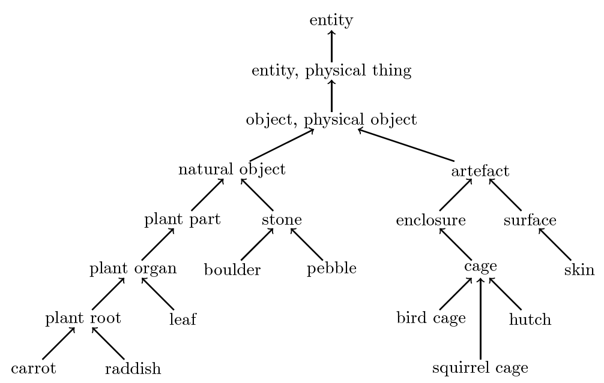

### Example: WordNet Excerpt

- **Hierarchy:** Every `pebble` is a `stone`, and every `stone` is a `natural object`.
- **The Root:** Every concept is a descendent of `entity`.
  - $p(\text{entity}) = 1$
  - Information Content: $\log 1 = 0$

Knowing a random term is a descendent of **entity** provides no added information. Conversely, the probability of a specific term like **pebble** is much lower, meaning its **Information Content** is correspondingly higher.

## Information Content (IC)

**Logic of Inheritance**

Recall that:  
$x$ `instance_of` $A$ AND $A$ `is_a` $B$ $\implies$ $x$ `instance_of` $B$.

- **Monotonicity**: $p$ is a monotonically increasing function as we move up the hierarchy.
  - If $c_i$ `is_a` $c_j$, then $p(c_i) \leq p(c_j)$.
- **Root Probability**: If the ontology has a unique root node $r$, then $p(r)=1$.

### Resnik’s Definition

The **Information Content (IC)** of a concept is the negative log of its probability:

$$\text{IC}(t) = -\log p(t)
\tag{1}$$

## Information Content (IC)

The base $b$ of the logarithm $log_b$ determines the unit of the IC:

| base | IC unit |
| --- | --- |
| 2 | *bit* |
| 3 | *trit* |
| $e$ | *nat* |
| 10 | *hartley* |

The unit selection has no impact on the output as long as the same unit is used consistently.

**Note**

When writing $log$ without base, we mean the natural logarithm.

## Intuition Behind IC

As the probability of a concept increases, its information content decreases. This mirrors information theory:

- **Common vs. Rare**: We gain less new information from an observation of a common event than from a rare one.
- **The Root Term**: Since the root subsumes all concepts:
  - $p(\text{root}) = 1$
  - $\text{IC}(\text{root}) = -\log(1) = 0$

**Summary**

The more specific a term is (lower probability), the higher its Information Content. The more general it is (higher probability), the lower its Information Content.

## Basic Properties of Information Content (IC)

**Mathematical Foundation**

Information Content relies heavily on the properties of logarithms. These identities are essential for calculating IC across different branches of an ontology.

The following logarithmic identities are fundamental to the behavior of $IC(t) = -\log p(t)$:

$$\begin{aligned}
\log 1 &= 0 \\
\log xy &= \log x + \log y \\
\log x^r &= r \log x \\
\log \frac{1}{x} &= - \log x \\
\log_a x &= \frac{\log x}{\log a}
\end{aligned}$$

## Entropy

- Let us assume we are analyzing a random variable $X$, which can take on one of a finite number of specific values $\left\{x_1,x_2,\ldots,x_n\right\}$ with a probability $\left\{p_1,p_2,\ldots,p_n\right\}$, where the probability of the outcome $x_i$ is $p_i$ with $0\leq p_i\leq 1$ and $\sum_{i=1}^n p_i=1$.
- We will use the notation $p(X=x)$ or simply $p(x)$ to denote the probability that the random variable $X$ takes on some specific value $x$, where $x\in \left\{x_1,x_2,\ldots,x_n\right\}$.
- We will refer to each of the specific values that $X$ can take on as *outcomes*.

Shannon defined the information content of an outcome $x$ as

$$h(x) = \log_2 \dfrac{1}{p(x)}
\tag{2}$$

## Entropy (2)

Note that because of the properties of logarithms, $\log_2 \frac{1}{p(x)} = -\log_2 p(x)$, which is the definition of information content. The *entropy* of the random variable $X$, written as $H(X)$, was defined by Shannon as the average information content of all of the possible outcomes of $X$.

$$H(X) = \sum_{i=1}^n p(x_i)\log_2\dfrac{1}{p(x_i)}
\tag{3}$$

## Entropy (3)

- The *unit* of entropy and information content depends on the logarithm base (*bit*, *nat*, …).
- The entropy of a random variable $X$ can be interpreted as the *uncertainty* of the random variable. For instance, if $X$ has only one outcome (i.e., $p(x')=1$ for some $x'$), then the entropy of $X$ is zero.

$$H(X) = p(x')\log_2\dfrac{1}{p(x')} = 1\times (-1)\times\log_2 1 = 0$$

## Entropy (4)

On the other hand the entropy of $X$ is maximized if there is maximal uncertainty about the outcome – this is the case if no outcome is more likely than the others, or stated differently, if $X$ follows a uniform distribution.

[figure not shown]

- Entropy of a random variable $X=\left\{\mathtt{0, 1}\right\}$ representing Bernoulli process such as a coin toss for different values of $p(X=1)$.
- Maximum entropy is achieved if $p(\mathtt{0}) = p(\mathtt{1}) = 0.5$, i.e., for a uniform distribution.

## Proof

We want to show: among all probability distributions on $n$ outcomes, entropy

$$H(p) = -\sum_{i=1}^n p_i \log p_i$$

is maximized by the **uniform** distribution $p_i = 1/n$.

- **Constraint:** $\sum_{i=1}^n p_i = 1$, with $p_i \geq 0$.
- The method of Lagrange multipliers allows us to find maximums/minimums subject to a constraint

## The Lagrangian

Introduce a multiplier $\lambda$ for the normalization constraint:

$$\mathcal{L}(p, \lambda) = -\sum_{i=1}^n p_i \log p_i \;-\; \lambda\left(\sum_{i=1}^n p_i - 1\right)$$

- At a stationary point, the gradient with respect to every $p_i$ must vanish, i.e., $\tfrac{\partial \mathcal{L}(p, \lambda)}{\partial p_i}=0$
- We have

$$\begin{align}
\frac{\partial \mathcal{L}}{\partial p_i} &= -\log p_i - 1 - \lambda = 0 \quad \Longrightarrow \quad p_i = e^{-1-\lambda}
\end{align}$$

- the right-hand side doesn’t depend on $i$, so every $p_i$ must be equal; denoting the the common value $c$:
  $$\sum_{i=1}^n p_i = \sum_{i=1}^n c = nc = 1 \quad \Longrightarrow \quad p_i = \frac{1}{n}\quad \text{for all } i$$

## The Hessian Matrix

$$\nabla^2 \mathcal{L} = \begin{bmatrix} -\dfrac{1}{p_1} & 0 & \cdots & 0 \\
0 & -\dfrac{1}{p_2} & \cdots & 0 \\
0 & 0 & \ddots & 0 \\
0 & 0 & \cdots & -\dfrac{1}{p_n}
\end{bmatrix}$$

Since $p_i > 0$, every diagonal entry is **negative**, and off-diagonal entries vanish.

$H(p)$ is therefore **strictly concave** — the unique critical point is a **global maximum**, not a saddle or minimum.

$$H(p) \leq H\left(\tfrac{1}{n}, \dots, \tfrac{1}{n}\right) = \log n$$

for every probability distribution $p$ on $n$ outcomes, with equality **iff** $p$ is uniform.

**Interpretation:** maximal uncertainty about the outcome corresponds exactly to maximal entropy — any deviation from uniformity introduces predictability and strictly lowers $H$.

## Entropy (5)

The function $IC(x) = -\log p(x)$ is a natural one for measuring information content, for several reasons.

- If there is no uncertainty, i.e., if $p(x=1)$, then $IC(x)= \log 1 = 0$.
- On the other hand, the information content can be arbitrarily large as the probability of an outcome goes to arbitrary small quantities: $\lim_{x\rightarrow 0}\log x = \infty$.
- Say we have two random variables, $X$ and $Y$, that are independent from one another. It is reasonable to assume that the information content of the outcomes $x$ and $y$ must be additive. This is a natural consequence of the logarithm, because

$$IC(x,y) = -\log_2 (xy) = -\log_2 x - \log_2 y = IC(x) + IC(y)$$

## Shannon’s Entropy: The Uniqueness Theorem

Claude Shannon’s definition of entropy is not arbitrary; it is the **only** function that satisfies three fundamental postulates.

**Theorem: Uniqueness of Entropy**

Let $P = \{p_1, p_2, \dots, p_n\}$ be the probabilities of outcomes $\{x_1, x_2, \dots, x_n\}$, where $p_i \geq 0$ and $\sum p_i = 1$.

A continuous function $H(P)$ satisfies the following:

1. **Maximality**: $H$ is maximized when $p_i = \frac{1}{n}$ for all $i$ (uncertainty is highest when all outcomes are equally likely).
2. **Additivity**: $H(AB) = H(A) + H_A(B)$. If $A$ and $B$ are independent, $H(AB) = H(A) + H(B)$.
3. **Expandability**: $H(p_1, \dots, p_n) = H(p_1, \dots, p_n, 0)$ (adding an impossible event does not change entropy).

**Then $H$ must take the form:**
$$H(p_1, p_2, \dots, p_n) = \lambda \sum_{i=1}^n - p_i \log p_i$$
where $\lambda$ is a positive constant (usually $\lambda=1$).

## Information Content in Gene Ontology (GO)

In the setting of GO, the probability of a term $t$ is the probability that a **randomly chosen** gene product (usually: protein) is annotated to that term.

- **The Root Term**: Assuming all genes are annotated to the root (the most general term):
  - $p(\text{root}) = 1$
  - $\text{IC}(\text{root}) = -\log_2(1) = 0$
- **General vs. Specific**:
  - Terms used for many genes have **low** IC.
  - Terms used for very few genes have **high** IC.

**Note**

This reflects “surprise”: discovering a gene is annotated to the root is expected, while discovering a rare, specific annotation provides significant information.

## IC: Numerical Examples

Assume we have a set of **256 annotated genes**:

| Genes Annotated to Term | Probability $p(t)$ | IC calculation ($-\log_2 p(t)$) | IC Value (bits) |
| --- | --- | --- | --- |
| 256 (All) | $256/256 = 1$ | $-\log_2(1)$ | **0** |
| 4 | $4/256$ | $-\log_2(4/256) = 8 - 2$ | **6** |
| 2 | $2/256$ | $-\log_2(2/256) = 8 - 1$ | **7** |
| 1 (Unique) | $1/256$ | $-\log_2(1/256)$ | **8** |

### Part 1: Information content

- Information content
- Entropy

### Part 2: Semantic similarity

- Definition of ontologies (review)
- Ontologies and biomedical research

### Part 3: Human Phenotype Ontology

- Phenotype and phenotypic feature
- HPO

### Part 4: Phenomizer & LIRICAL

- Phenomizer algorithm
- LIRICAL algorithm

## Semantic Similarity ($t_1 \leftrightarrow t_2$)

Resnik defined similarity between two terms based on the **Information Content of their Most Specific Ancestor (MSA)**.

$$\text{IC}(t) = -\log p(t)$$

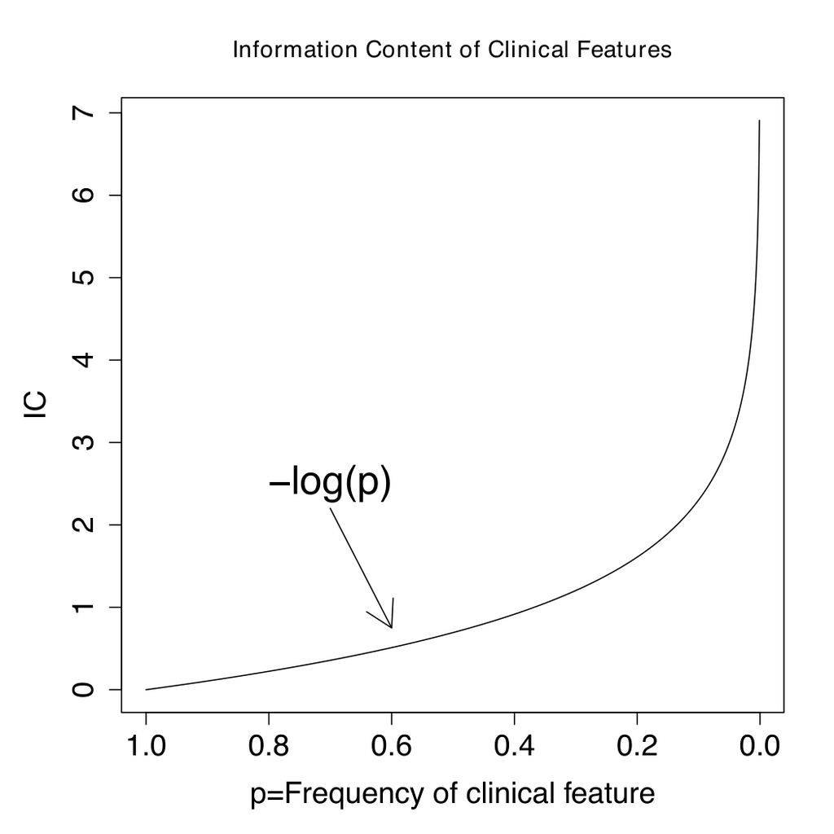

### Resnik Similarity

The similarity is the IC of the most specific ancestor $a$ in the set of common ancestors $\mathcal{A}(t_1, t_2)$:

$$\mathrm{sim}(t_1, t_2) = \max_{a \in \mathcal{A}(t_1, t_2)} [-\log p(a)]
\tag{4}$$

We refer to this as the **IC of the Most Specific Ancestor**: $\text{IC}(a')$, or **MICA**

## Semantic similarity: An example

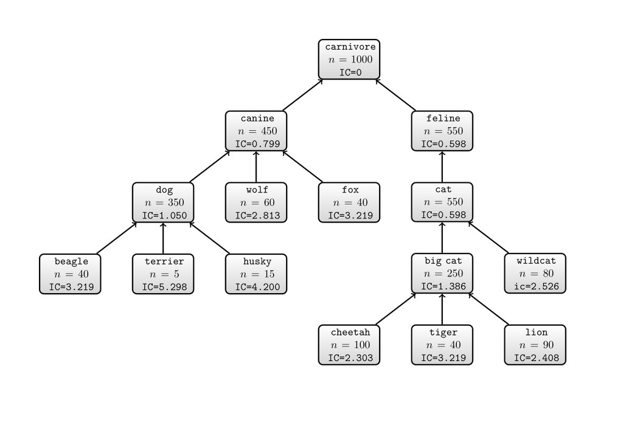

An ontology with annotated items

## Semantic similarity

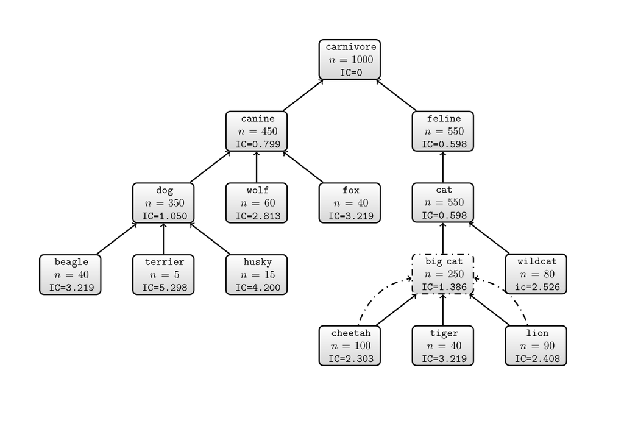

`lion` and `cheetah` are similar

## Semantic similarity

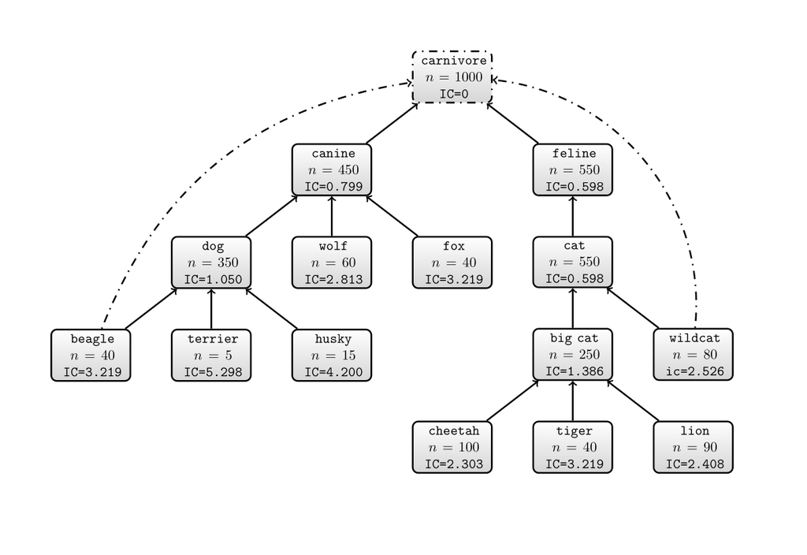

`beagle` and `wildcat` are not $\ldots$

### Part 1: Information content

- Information content
- Entropy

### Part 2: Semantic similarity

- Definition of ontologies (review)
- Ontologies and biomedical research

### Part 3: Human Phenotype Ontology

- Phenotype and phenotypic feature
- HPO

### Part 4: Phenomizer & LIRICAL

- Phenomizer algorithm
- LIRICAL algorithm

## Bioinformatics for Medicine?

- How exactly do we calculate the similarity between diseases, symptoms, patients, and more?

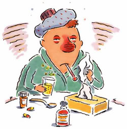

Common Cold

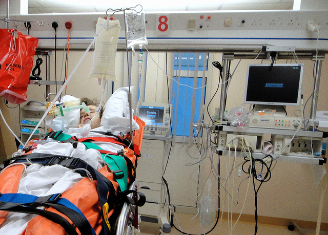

ICU

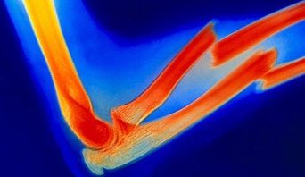

Broken Bone

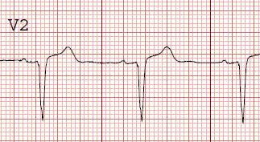

EKG

## A tale of two footballs

$$\begin{equation*}
\mbox{American Football} = \mbox{Football} \neq
\mbox{Football} = \mbox{European Football} = \mbox{Soccer}
\end{equation*}$$

[figure not shown]

A football $\ldots$

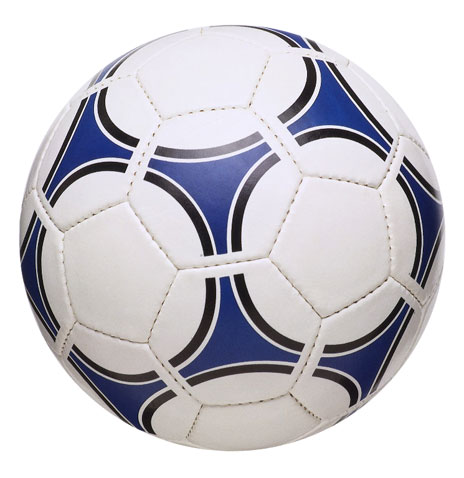

A football $\ldots$

When you see `football`, your computer sees: 0100011001101111011011110111010001100010011000010110110001101100

## A tale of two fibrillations

$$\begin{equation*}
\mbox{muscle fibrillation} = \mbox{fibrillation} \neq
\mbox{fibrillation} = \mbox{ventricular fibrillation}
\end{equation*}$$

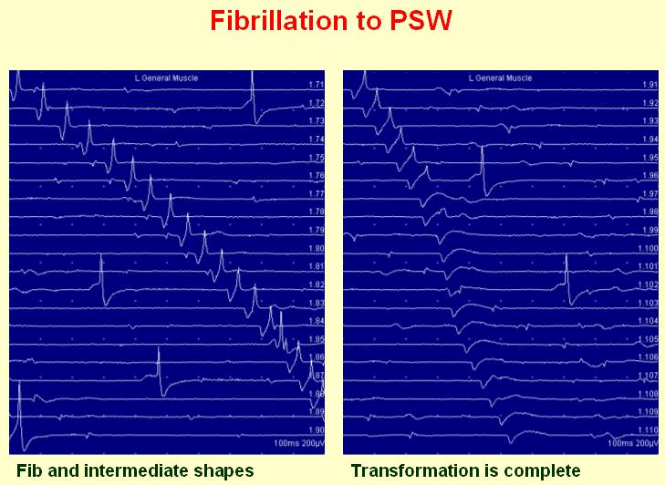

fibrillation $\ldots$

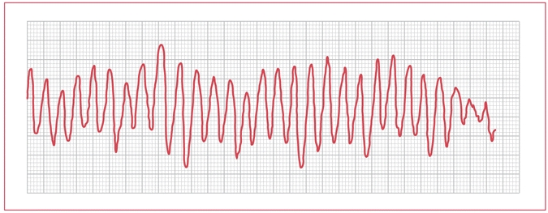

fibrillation $\ldots$

When you see `fibrillation`, your computer sees: 011001100110100101100010011100100110100101101100011011000110000101110100011010010110111101101110

## What is a phenotype ontology?

**Core Purpose**

Precise language (and thinking), interoperability, and improved database models to reliably capture and interpret phenotype information.

- A **medical** phenotype ontology describes the individual manifestations of diseases:
  1. Signs
  2. Symptoms
  3. Laboratory findings
  4. Imaging studies
  5. *etc.*

Robinson PN, Webber C (2014) [Phenotype ontologies and cross-species analysis for translational research. *PLoS Genet* **10**:e1004268](https://pubmed.ncbi.nlm.nih.gov/24699242/).

## Deep Phenotyping

The precise and comprehensive analysis of phenotypic abnormalities.

- Individual components of the phenotype are observed and described using a controlled vocabulary.
- Deep phenotyping information is critical for:
  - Computational differential diagnostic tools.
  - Genotype-phenotype correlation.
  - Scientific examination of human disease.

PN Robinson (2012) [Deep phenotyping for precision medicine. *Hum Mutat* **33**:777–780](https://pubmed.ncbi.nlm.nih.gov/22504886/). Special Issue of Human Mutation on Deep Phenotyping

## Ontologies for Medicine and Translational Research

**Core Purpose**

Ontologies have two major (interrelated) **use cases**

- Interoperability between databases
- Foundation for algorithms and computational tools

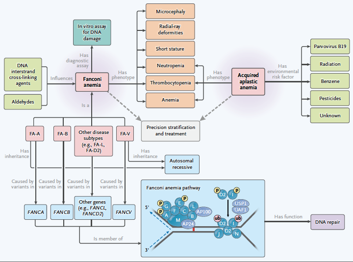

## Ontologies: Interoperability

[figure not shown]

[figure not shown]

- Human genetics is becoming a data-driven science
- Global Alliance for Genomics and Health (GA4GH) and other groups are defining standards to exchange and integrate information between databases across the globe
- This is particularly difficult for **clinical data**!

Brookes and Robinson (2015) [Human genotype-phenotype databases: aims,challenges and opportunities, *Nature Reviews Genetics* **16**:702-15](https://pubmed.ncbi.nlm.nih.gov/26553330/)

## Interoperability: What’s the problem?

- Phenotypic descriptions that are very evocative for humans<sup>1</sup>:
  - myopathic electromyography
  - still walking 25 years after onset
- The following descriptions mean the same thing to you: `generalized amyotrophy`, `generalized muscle atrophy`, `muscular atrophy, generalized`, (etc)
- Many publications have little<sup>2</sup> information about the actual phenotypic features seen in patients with particular diseases and variants
- Databases cannot talk to one another about phenotypes

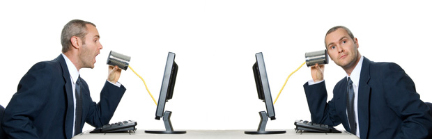

[^2]: Unfortunately computers, being significantly dumber than humans, don’t quite “get” it…
[^3]: or none at all

## Ontologies: Interoperability

An ontology provides a **standardised “Term”** for each entity in its domain that can be used for data exchange.

| Field | Description |
| --- | --- |
| **ID** | HP:0000256 |
| **Name** | Macrocephaly |
| **Definition** | Occipitofrontal (head) circumference greater than 97th centile compared to appropriate, age matched, sex-matched normal standards. Alternatively, an apparently increased size of the cranium. |
| **Synonyms** | Large head, big head, large cranium, large calvaria, Increased head circumference, … |
| **Xrefs** | MeSH:D058627, UMLS:C0221355, SNOMED CT:19410003, ICHPT:T0028, EoM:1d53660e657259f0, … |
| **Translations** |  |

## Ontologies as Computational Tools

Ontologies are used for myriad applications in biomedical research and translational applications. The greatest common denominator is: **Compute over human knowledge!**

### Applications

- Functional profiling in high-throughput experiments
- Network biology
- Model, reason and manage complex data systems (e.g., IBM Watson)
- Natural Language Processing
- *et cetera*

[figure not shown]

Haendel, Chute, Robinson (2018) Classification, Ontology, and Precision Medicine.  
*N Eng J Med* **379**:1452-1462

## The Human Phenotype Ontology

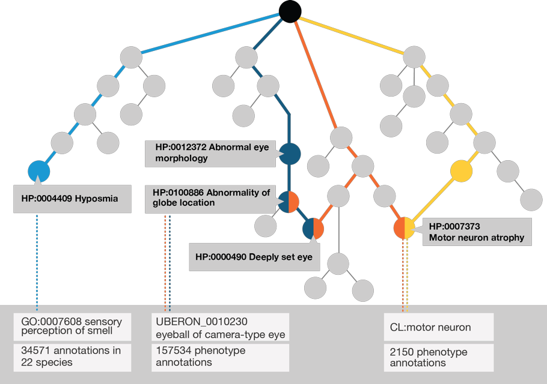

Robinson Am J Hum Genet 2008  
Köhler Am J Hum Genet 2009  
Robinson Clin Genet. 2010  
Schulz BMC Bioinformatics. 2011  
Köhler Hum Mutat. 2012  
Bauer Bioinformatics 2012  
Köhler Nucleic Acids Res 2014  
Köhler J Med Genet 2014  
Zemojtel Sci Transl Med. 2014  
Robinson PLoS Genet. 2014  
Robinson Genome Res. 2014  
Groza Am J Hum Genet 2015  
Groza Database (Oxford). 2015  
Smedley Nat Protoc 2015  
Smedley Genome Med. 2015  
Smedley Am J Hum Genet. 2016  
Köhler Nucleic Acids Res 2017  
Vasilevsky Nat Genet 2018  
Köhler Nucleic Acids Res 2019  
Köhler Curr Protoc Hum Genet. 2019  
Carmody Orphanet J Rare Dis. 2020  
Köhler Nucleic Acids Res 2021  
Dhombres Am J Med Genet C 2022  
Gargano Nucleic Acids Res 2024

- **>19,000 terms**
- 244,440 annotations for **8,223 monogenic or chromosomal diseases**
- [http://www.human-phenotype-ontology.org](https://hpo.jax.org/app/)

### Part 1: Information content

- Information content
- Entropy

### Part 2: Semantic similarity

- Definition of ontologies (review)
- Ontologies and biomedical research

### Part 3: Human Phenotype Ontology

- Phenotype and phenotypic feature
- HPO

### Part 4: Phenomizer & LIRICAL

- Phenomizer algorithm
- LIRICAL algorithm

## Phenotypic Similarity Algorithms

**Goal**: Calculate a similarity between a set of query terms and computational disease models.

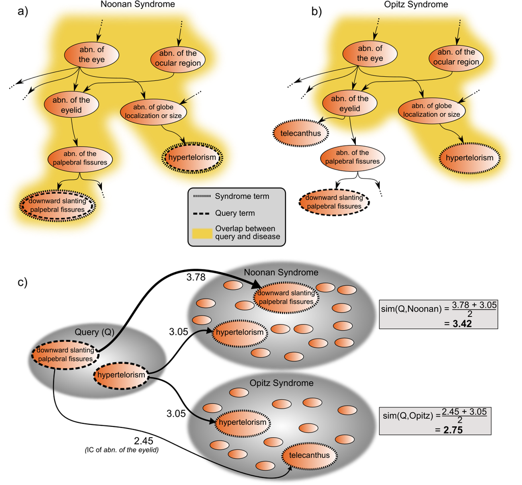

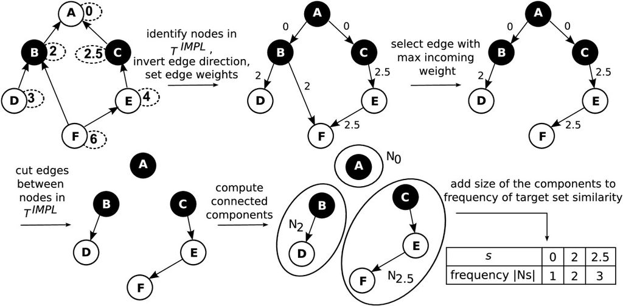

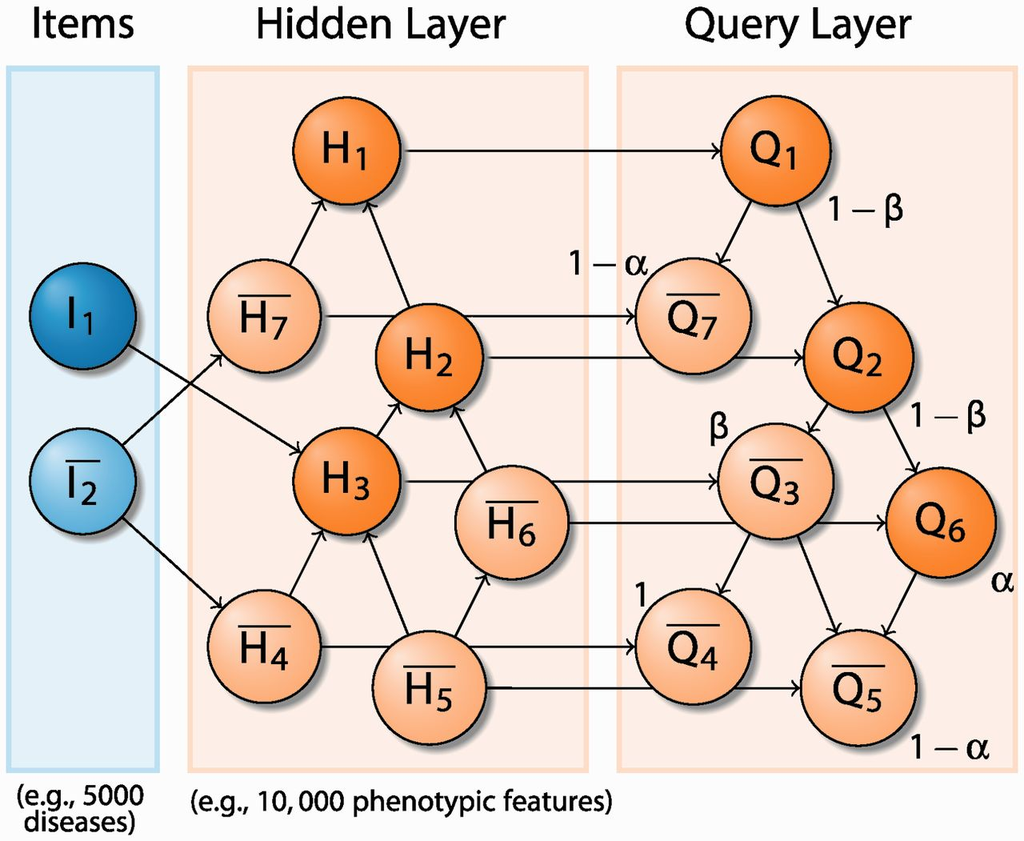

**Phenomizer**  
Köhler et al. (2009) *Am J Hum Genet* **85**:457-64

**Exact Score Distribution**

Schulz MH et al (2011) *BMC Bioinformatics* **12**:441

**BOQA**

Bauer et al. (2012) *Bioinformatics* **28**:2502-8

- Today, we will go into detail about two phenotype matching algoriths, Phenomizer and LIRICAL.

## Ontological Diagnostics

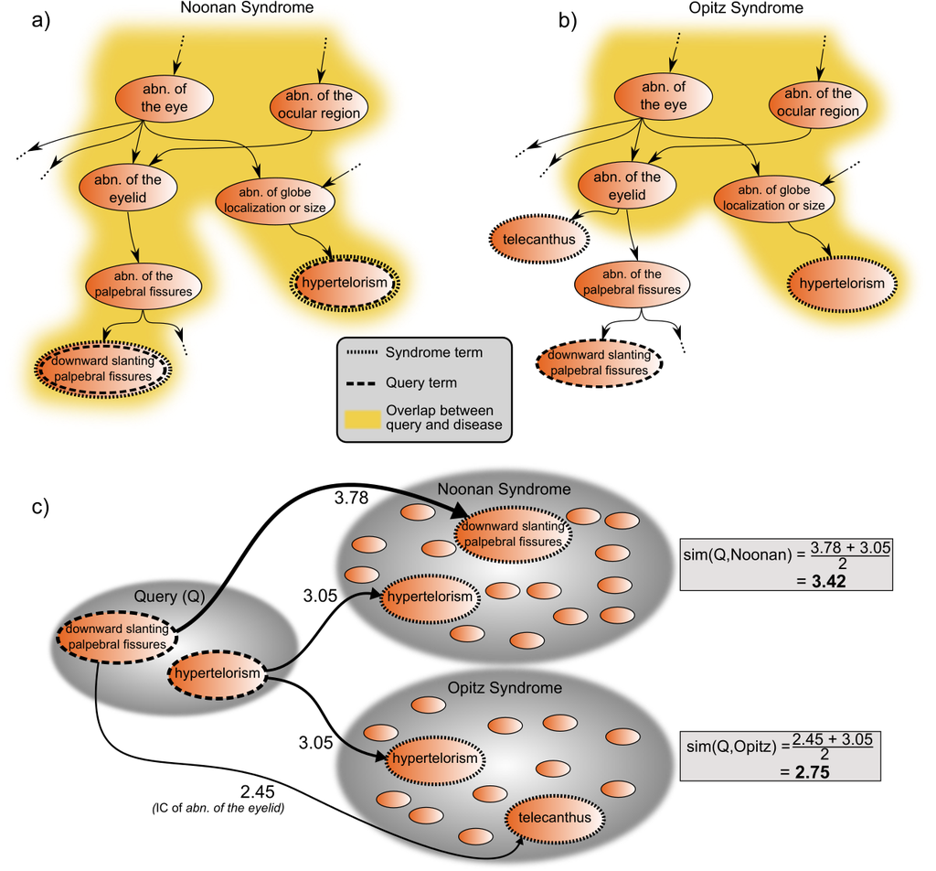

$$\text{sim}(\color{orange}{Q} \rightarrow \color{blue}{d}) = \text{avg} \left[ \sum_{s \in \color{orange}{Q}} \max_{t \in \color{blue}{d}} \text{sim}(s,t) \right]$$

$\color{orange}{Q}$: Query terms

$\color{blue}{d}$: Disease terms

## The Phenomizer

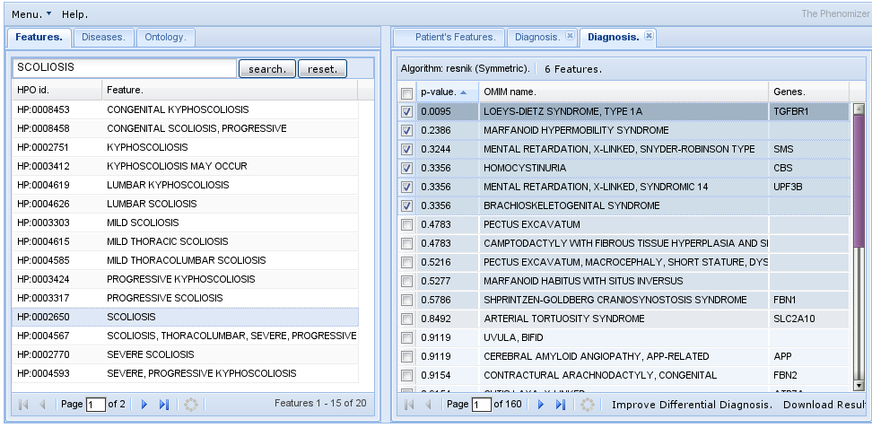

- The **Phenomizer**: The first algorithm/software tool for supporting differential diagnostics with semantic similarity analysis
- Sebastian Köhler et al. (2009) Clinical Diagnostics with Semantic Similarity Searches in Ontologies. *Am J Hum Genet*, **85**:457–64.
- Online version supported 2009-2022…no longer available.

## The query

**Query terms**: The HPO is frequently used to create a set of terms that accurately describe the observed clinical abnormalities of an individual being evaluated for suspected rare genetic disease.

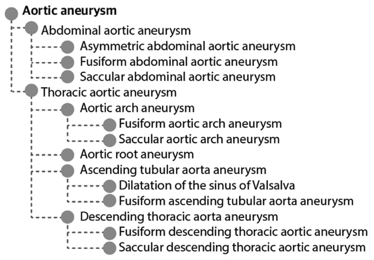

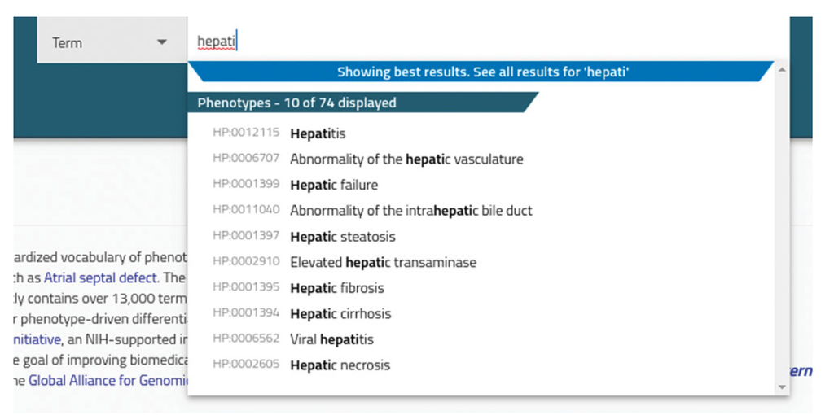

- Physicians choose terms to represent the clinical anomalies seen in a patient<sup>1</sup>
- Many tools are available. Some tools enable users to choose HPO terms by navigating the HPO hierarchy or by using autocomplete functions.
[^4]: The word “patient” is a role played by an individual who presents for medical treatment or diagnostics, but does not describe the individual him- or herself. In many contexts, the word “individual” is preferred.

## The query

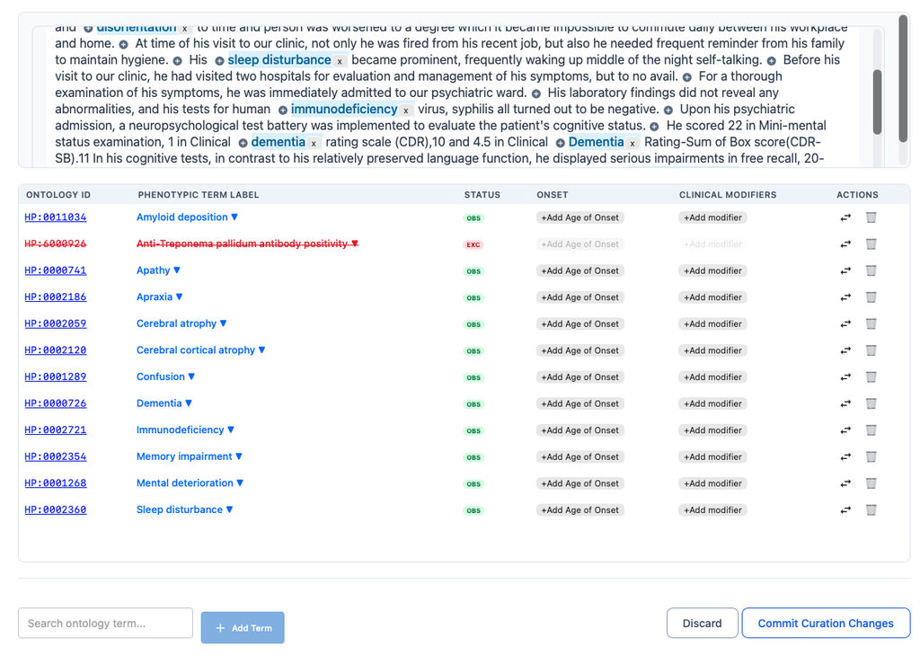

- Various text mining (named entity recognition) tools are available
- For more information on how to choose HPO terms to represent clinical data, see [Köhler S, et al., (2019) Encoding Clinical Data with the Human Phenotype Ontology for Computational Differential Diagnostics. Curr Protoc Hum Genet](https://pubmed.ncbi.nlm.nih.gov/31479590/)
- phenoboard

## Disease model(s)

**Disease model**: The HPO is frequently used to create a set of terms that accurately describe the observed clinical abnormalities of an individualbeing evaluated for suspected rare genetic disease.

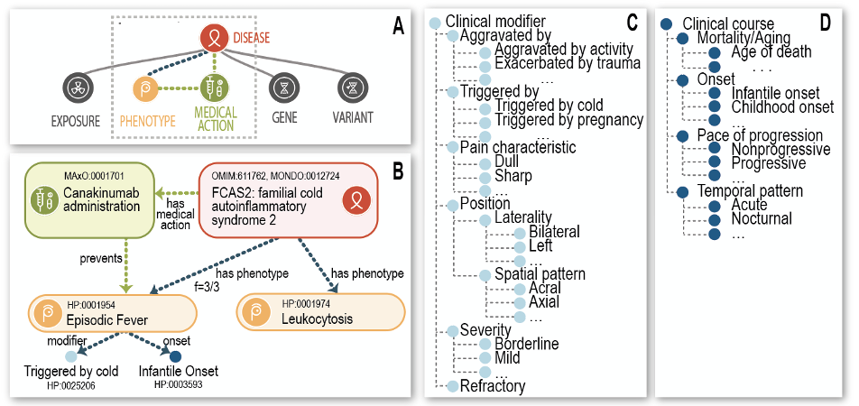

- The HPO project has $>8000$ disease models
- Algorithms such as Phenomizer compare the query with each model to determine a ranked list of models that best match the query
- Algorithms differ in how they calculate the strength of the **match**

## Fuzzy, specificity weighted matching

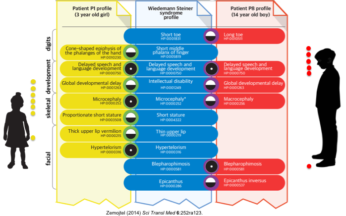

## Example

**query**:

- Pulmonic stenosis HP:0001642
- Upslanted palpebral fissure HP:0000582
- Proportionate short stature HP:0003508
- Headache HP:0002315

For demo purposes, let’s create two simplified disease models

**Noonan syndrome type 1 (NS1)**

- Pulmonic stenosis HP:0001642
- Short stature HP:0004322
- Downslanted palpebral fissures HP:0000494

**Neurodevelopmental disorder 1 (NDD1)**

- Short stature HP:0004322
- Primary microcephaly HP:0011451
- Gray matter heterotopia HP:0002282

## Example

[output not shown]

- Information content of *Upslanted palpebral fissure* is 3.46, that of *Downslanted palpebral fissure* is 3.01. To calculate the most informative common ancestor, we go to their common parent *Slanting of the palpebral fissure* HP:0200006, which has an IC of 2.59
- *Short stature* is the direct parent of *Proportionate short stature*, and so the MICA is the IC of *Short stature*
- Noonan syndrome 1 receives a higher score than Neurodevelopmental disorder 1, and so NS1 would be ranked before NDD1
- The same process is performed for all 8500 candidate diseases to generate the final ranking (**prioritization**)

## Example

The table in the previous slide demonstrates how to calculate the phenomizer score
$$\mathrm{sim}(Q\rightarrow D) = \mathrm{avg} \sum_{s\in Q}\max_{t\in D}\mathrm{sim}(s,t)$$
- $\mathrm{sim}(s,t)$ is calculated as the IC of the maximally informative common ancestor (MICA), see Equation 4.

**From raw score to *p*-value**:

Raw similarity scores aren’t directly comparable across diseases:

- A disease with **many annotated terms** has more chances for a lucky match
- A **small, specific** query profile behaves differently than a large, vague one
- To make the Phgenomizer score comparable across 8500 diseases, we want to know: *How much does a score actually support a disease, given the query’s and the disease’s HPO term count and specificity?*

## Empirical *p*-value via simulation

For each candidate disease $D$:

1. Generate $N$ **random query profiles** of the same size as the observed query (terms sampled from the HPO term/annotation universe)
2. Compute the fuzzy similarity score between each random query and $D$, exactly as for the real query
3. This builds a **null distribution** of scores specific to $D$’s phenotype profile and the query size
4. Empirical *p*-value:

$$p = \frac{\#\{\text{random scores} \geq \text{observed score}\}}{N}$$

- Diseases are then ranked by $p$-value rather than raw score, making rankings comparable across diseases with very different profile sizes
- This was the basis of the original Phenomizer algorithm

## Empirical *p*-value via simulation

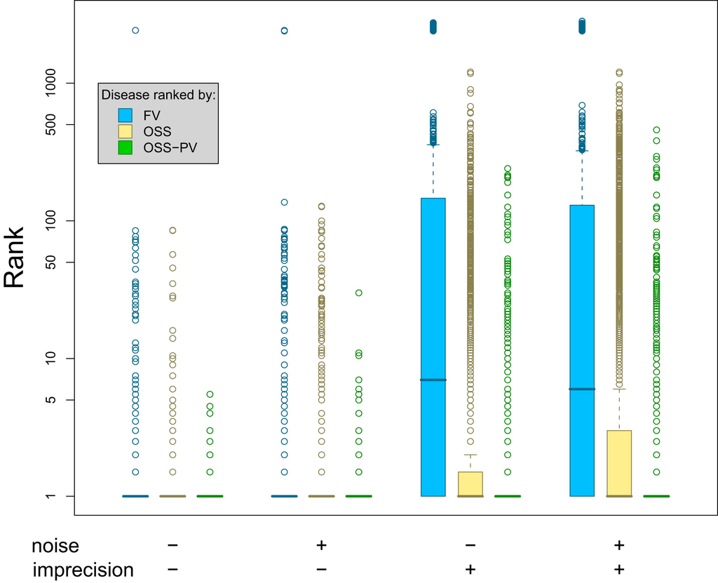

- Feature vector (FV) method, ontological similarity search (OSS), and p value (OSS-PV)

Köhler S, et al. (2009) [Clinical diagnostics in human genetics with semantic similarity searches in ontologies. *Am J Hum Genet* **85**:457-64](https://pubmed.ncbi.nlm.nih.gov/19800049/)

## LIRICAL

- LIRICAL is a newer phenotypic-driven prioritization algorithm that leverages the likelihood ratio test

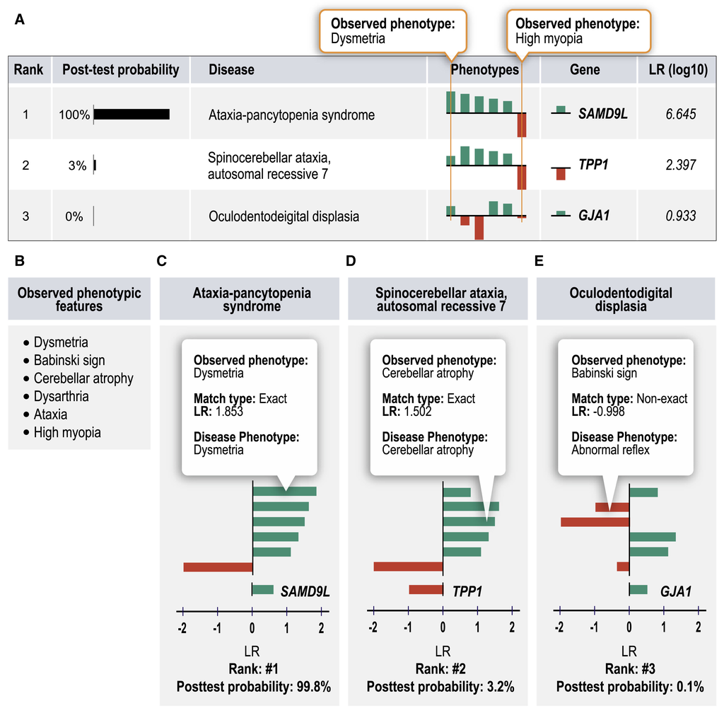

- We will first explain the basic concepts of the likelihood ratio test (LRT) and then present LIRICAL in more detail.